# Estudios de Informática, Multimedia y Telecomunicaciones

# Minería de datos: Herramientas del Aula

UOC

Febrero 2020

> A lo largo de esta asignatura trabajaremos distintos algoritmos propios de la minería de datos a través del lenguaje de programación R. Para ello utilizaremos tres herramientas de trabajo que se presentan en este documento. Cubriremos conceptos como el porqué de cada una de ellas, enlaces para proceder a su instalación y algunos ejemplos básicos.

> Las tres herramientas son:  
> - Un lenguaje de presentación de documentos (markdown)  
> - Un lenguaje de programación (R)  
> - Un entorno de trabajo (RStudio) que integra los dos anteriores.

> Para aquellos que no estáis en absoluto familiarizados con entornos de programación, no os preocupéis porque se os dará todo el soporte necesario a través del aula del laboratorio virtual y de la propia asignatura de minería de datos.

## 0.1 Porqué lenguaje R

1. Es actualmente un **estándar** para realizar tareas especialmente intensivas en estadística, matemáticas y minería de datos.
2. Se trata de un software de **distribución libre** y constantemente mejorado y ampliado por una comunidad especialmente activa.
3. Existe mucha documentación en la web: a nivel de manuales, tutoriales y foros.

## 0.2 Porqué lenguaje Markdown

1. Markown nos permite redactar en modo texto plano y mediante una relación muy simple de símbolos o marcadores, es posible generar formatos estándar de presentación como HTML, MSWord, PDF o LaTex. Para saber más sobre su sintaxis podéis acceder a http://rmarkdown.rstudio.com.
2. Su integración en RStudio nos permitirá a partir de un texto plano:
   - Ejecutar código R
   - Dar formato documental (HTML, MSWord, pdf, LaTex, …) al texto
   - Integrar en un solo documento la explicación y el resultado de la ejecución R
3. Permite que nuestro trabajo sea fácilmente **interpretable** y además **reproducible** por parte de terceros.
4. Existe mucha documentación en la web: a nivel de manuales, tutoriales y foros

## 0.3 Porqué entorno de trabajo RStudio

1. RStudio nos permite pasar del concepto consola o *shell* al concepto entorno de trabajo o *workbench*.
2. Cumple con los principios de la [reproducibilidad de estudios](http://en.wikipedia.org/wiki/Reproducibility). De este modo se facilita el proceso de elaboración de trabajos de forma que sean *reproducibles por terceros*.
3. Cumple con los principios de la [Programación literal](http://en.wikipedia.org/wiki/Literate_programming), simplificando el proceso de documentación basada en el paradigma de la *reproducibilidad de estudios*.

## 0.4 Instalación de herramientas

### 0.4.1 Lenguaje R

Instalar la última versión de R. http://cran.r-project.org/

Además tenéis a disposición la wiki del laboratorio virtual de la UOC sobre R, en las que encontraréis guías de instalación para el software utilizado en cada asignatura. En nuestro caso, R para minería de datos.

1. Wiki del laboratorio R http://cv.uoc.edu/webapps/xwiki/wiki/mat71575es

### 0.4.2 Paquetes R necesarios para RStudio

Para que RStudio funcione correctamente, es necesario que R tenga previamente instalados una lista de paquetes adicionales. Para poder generar documentos MSWord y HTML a partir de markdown, instalad los siguientes paquetes R.

Pare ello ejecutad el siguiente código en una consola R.

`install.packages(c("knitr","yaml","htmltools","caTools","bitops","markdown"))`

### 0.4.3 RStudio

Instalar la última versión de RStudio desktop http://www.rstudio.com/products/rstudio/download/

## 0.5 Primeros pasos

### 0.5.1 Código R

Desde RStudio ( Archivo - Nuevo archivo - R Script ), escribid el siguiente código:

Para visualizar los primeros registros del juego de datos iris

```r
head(iris)
```

```
##   Sepal.Length Sepal.Width Petal.Length Petal.Width Species
## 1          5.1         3.5          1.4         0.2  setosa
## 2          4.9         3.0          1.4         0.2  setosa
## 3          4.7         3.2          1.3         0.2  setosa
## 4          4.6         3.1          1.5         0.2  setosa
## 5          5.0         3.6          1.4         0.2  setosa
## 6          5.4         3.9          1.7         0.4  setosa
```

Para generar un gráfico con dos atributos del juego de datos

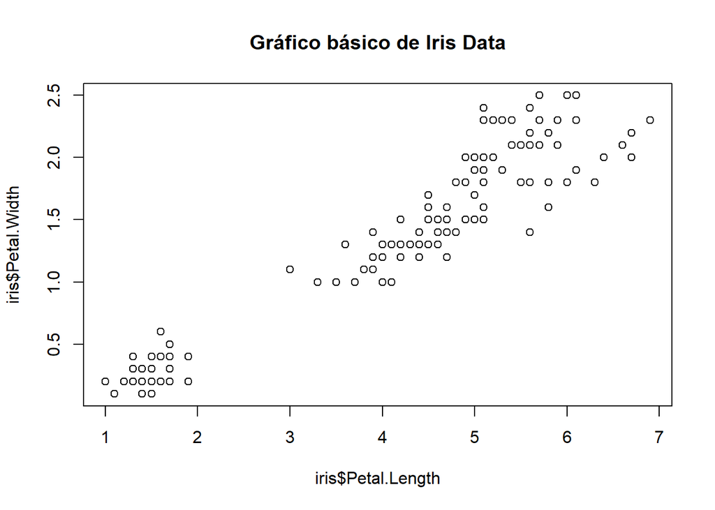

```r
plot(iris$Petal.Length, iris$Petal.Width, main="Gráfico básico de Iris Data")
```

A pesar de que no es objetivo de la asignatura llegar a tener un gran dominio en el lenguaje R, sí que merecería la pena echar un vistazo al Manual oficial R: http://cran.r-project.org/doc/manuals/r-release/R-lang.html

### 0.5.2 Documento R Markdown

Este documento ha sido creado con R Markdown, desde RStudio ( Archivo - Nuevo archivo - R Markdown )

Si tenéis abierto el documento 75.584-Herramientas.Rmd en RStudio, simplemente usad el botón “knit” situado justo al lado de la lupa de búsqueda. Veréis como se genera un documento html con el mismo nombre.

Este documento html contiene una fusión del texto redactado y el código R ejecutado.